# Biostat 203B Homework 2

Due Feb 5 @ 11:59PM

```r
knitr::opts_chunk$set(echo = TRUE, cache = TRUE, cache.lazy = TRUE)
library(tidyverse)
library(data.table)
library(lubridate)
os <- sessionInfo()$running
if (str_detect(os, "Linux")) {
  mimic_path <- "/usr/203b-data/mimic-iv"
} else {
  mimic_path <- "C:/Users/Kelly Li/Documents/R/B203b/biostat-203b-2021-winter/HW2"
}
```

Use tidyverse (ggpot2, dplyr) to explore the [MIMIC-IV](https://mimic-iv.mit.edu) data introduced in [homework 1](https://ucla-biostat203b-2021winter.github.io/hw/hw1/hw1.html).

```r
system(str_c("tree -s -L 2 ", shQuote(mimic_path)), intern = TRUE) #This may not work since it is on my windows system
```

```
## [1] "Too many parameters - -L"
```

## Q1. PhysioNet credential

At this moment, you should already get credentialed on the PhysioNet. Please include a screenshot of your `Data Use Agreement for the MIMIC-IV (v0.4)`.

```r
getwd()
```

```
## [1] "C:/Users/Kelly Li/Documents/R/B203b/biostat-203b-2021-winter/HW2"
```

```r
knitr::include_graphics("datauseagree.pdf")
```

[figure not shown]

## Q2. `read.csv` (base R) vs `read_csv` (tidyverse) vs `fread` (data.table)

There are quite a few utilities in R for reading data files. Let us test the speed of reading a moderate sized compressed csv file, `admissions.csv.gz`, by three programs: `read.csv` in base R, `read_csv` in tidyverse, and `fread` in the popular data.table package. Is there any speed difference?

In this homework, we stick to the tidyverse.

```r
system.time(read.csv("admissions.csv.gz"))
```

```
##    user  system elapsed
##    7.70    0.17    8.14
```

```r
system.time(read_csv("admissions.csv.gz"))
```

```
##    user  system elapsed
##    2.72    1.26    4.27
```

```r
system.time(fread("admissions.csv.gz"))
```

```
##    user  system elapsed
##    1.19    0.45    2.44
```

## Q3. ICU stays

`icustays.csv.gz` (https://mimic-iv.mit.edu/docs/datasets/icu/icustays/) contains data about Intensive Care Units (ICU) stays. Summarize following variables using appropriate numerics or graphs:

- how many unique `stay_id`?
- how many unique `subject_id`?
- length of ICU stay
- first ICU unit
- last ICU unit

```r
icu <- read_csv("icustays.csv.gz")
```

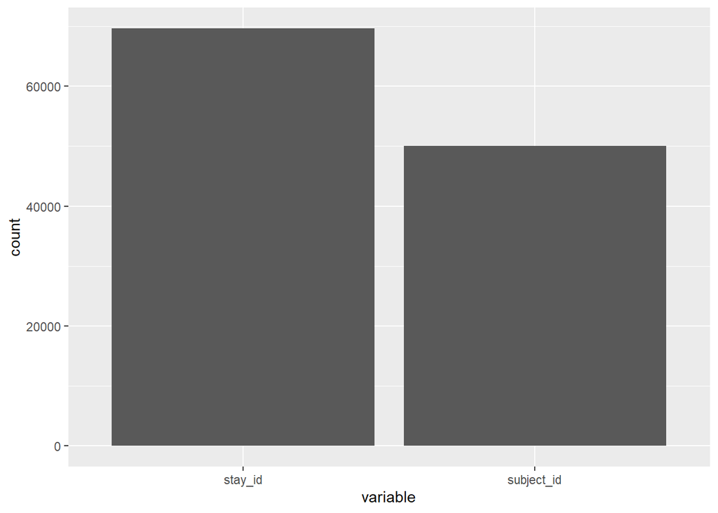

```r
#Find unique counts for icu and create a table for ggplot to read
count <- summarise_all(icu, n_distinct) %>%
  pivot_longer(cols = everything(),
               names_to = "variable",
               values_to = "count")

#plot for unique subject IDs
ggplot(subset(count, variable %in% c("subject_id", "stay_id"))) +
  geom_col(mapping = aes(x = variable, y = count))
```

There are 50048 unique subject IDs, and 69619 unique stay IDs.

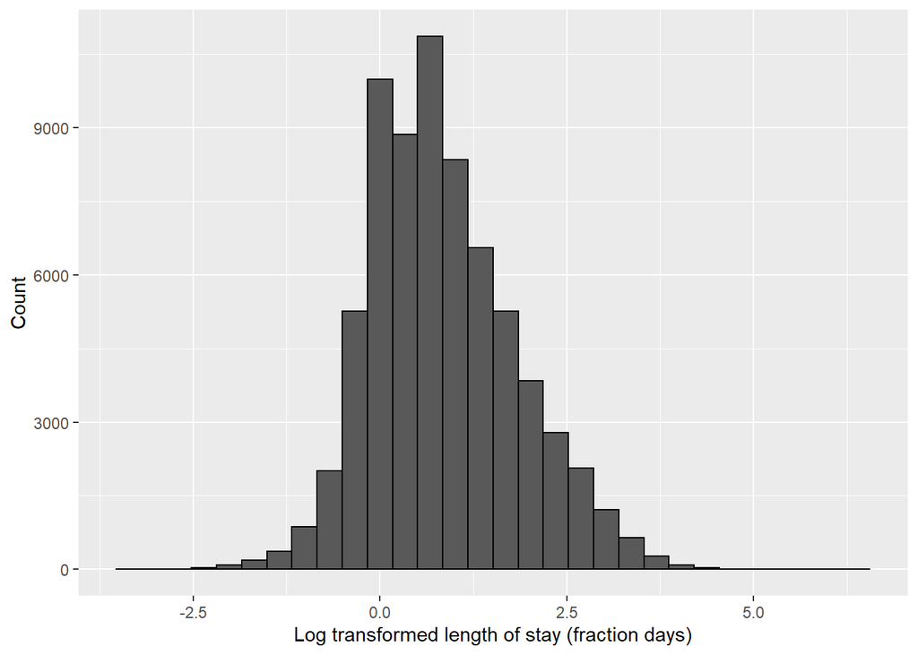

```r
icu <- mutate(icu,
              loglos = log(los))
ggplot(icu) +
  geom_histogram(mapping = aes(x = loglos),
                 color = "black") +
  xlab("Log transformed length of stay (fraction days)") +
  ylab("Count")
```

Since length of stay was heavily right-skewed, a log transformation was performed in order to create a histogram of the counts.

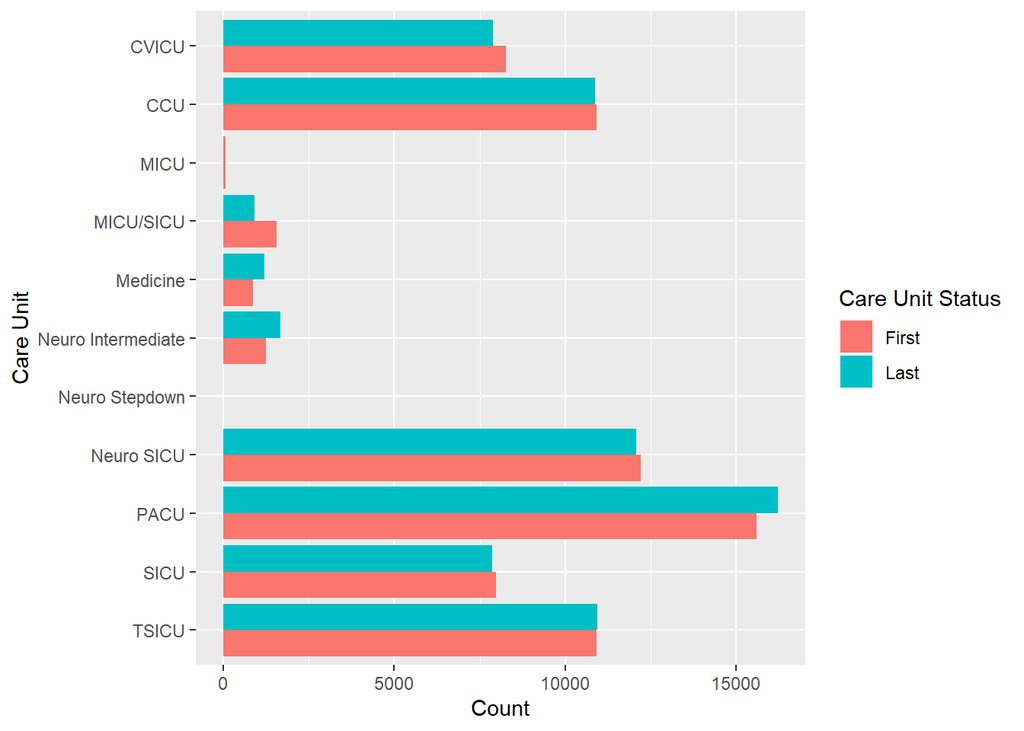

```r
#Creating icu data set for grouped bar plot
icu1 <- gather(icu, firstlast, unit, c(first_careunit, last_careunit))

ggplot(icu1) +
  geom_bar(mapping = aes(y = unit,
                         fill = firstlast),
           position = "dodge") +
  scale_y_discrete(labels = c("TSICU", "SICU", "PACU", "Neuro SICU",
                              "Neuro Stepdown", "Neuro Intermediate",
                              "Medicine", "MICU/SICU", "MICU",
                              "CCU", "CVICU")) +
  scale_fill_discrete(name = "Care Unit Status",
                      labels = c("First", "Last")) +
  xlab("Count") +
  ylab("Care Unit")
```

A grouped histogram for patient counts of first and last ICU in which they were cared for, displayed by unit type.

## Q4. `admission` data

Information of the patients admitted into hospital is available in `admissions.csv.gz`. See https://mimic-iv.mit.edu/docs/datasets/core/admissions/ for details of each field in this file. Summarize following variables using appropriate graphs. Explain any patterns you observe.

- admission year
- admission month
- admission month day
- admission week day
- admission hour (anything unusual?)
- number of deaths in each year
- admission type
- number of admissions per patient
- admission location
- discharge location
- insurance
- language
- martial status
- ethnicity
- death

Note it is possible that one patient (uniquely identified by the `subject_id`) is admitted into hospital multiple times. When summarizing some demographic information, it makes sense to summarize based on unique patients.

```r
#Creating data sets for plotting
adm <- read_csv("admissions.csv.gz")
#Create columns for year, month, day, and time
adm <- adm %>% mutate(year = year(admittime),
                      month = month(admittime,
                                    label = TRUE),
                      mday = mday(admittime),
                      wday = wday(admittime,
                                  label = TRUE),
                      hour = hour(admittime)) %>%
  add_count(year, hospital_expire_flag,
            sort = TRUE,
            name = "yeardeathcount") %>%
  add_count(subject_id,
            name = "admitcount")

#Filters data for only patients who died
yearlydeaths <- adm[adm$hospital_expire_flag == 1,]

#Filter admissions to get data set containing only first admit per patient
adm1 <- adm %>% arrange(desc(admittime)) %>%
  distinct(subject_id,
           .keep_all = TRUE)
```

For demographic information based off individual patients, a filtered version of admissions data is used to only account for the most recent admit per person. These demographics are insurance, language, marital status, and ethnicity. This is to give the most “up-to-date” summary statistics by person.

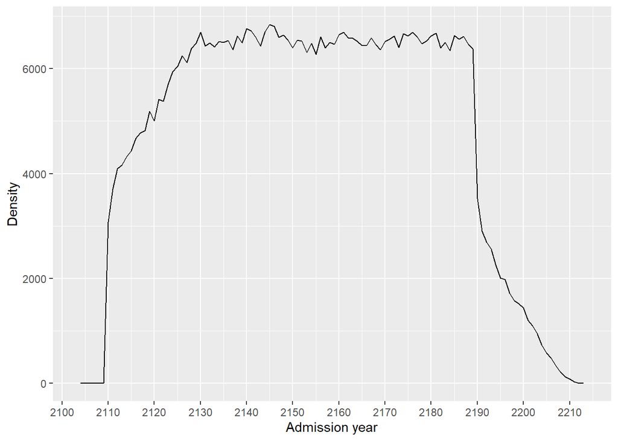

```r
#Year plot
ggplot(adm) +
  geom_freqpoly(mapping = aes(x = year),
                binwidth = 1,
                color = "black") +
  scale_x_continuous(n.breaks = 10) +
  xlab("Admission year") +
  ylab("Density")
```

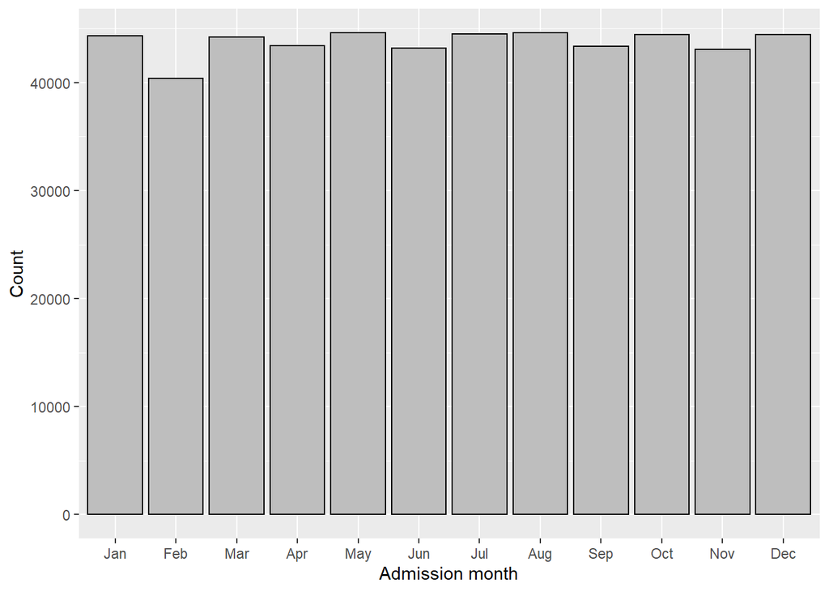

```r
#Month plot
ggplot(adm) +
  geom_bar(mapping = aes(x = month),
           fill = "grey",
           color = "black") +
  xlab("Admission month") +
  ylab("Count")
```

```r
#day plot
ggplot(adm) +
  geom_freqpoly(mapping = aes(x = mday),
                binwidth = 1,
                color = "black") +
  scale_x_continuous(n.breaks = 10) +
  xlab("Admission month day") +
  ylab("Count")
```

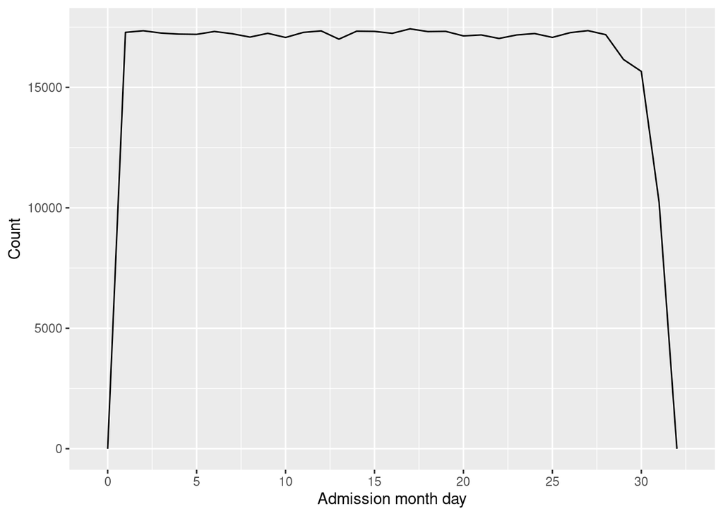

[figure not shown]

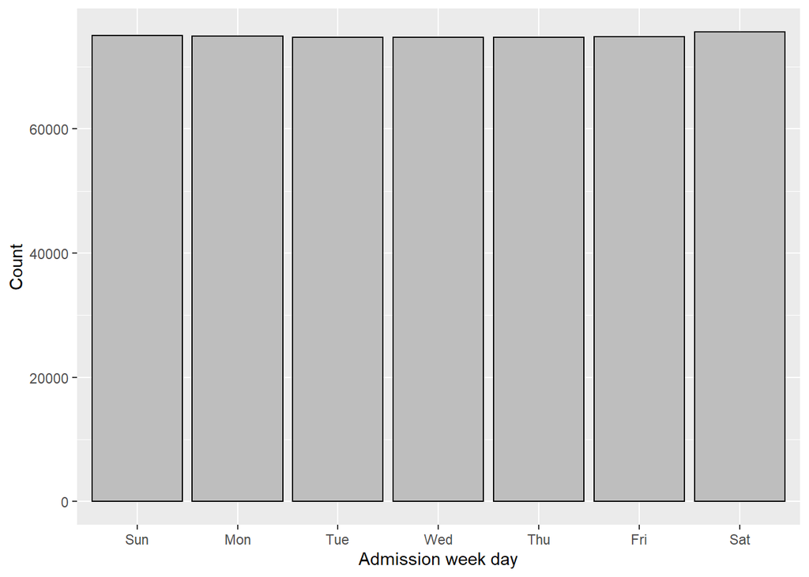

```r
#weekday plot
ggplot(adm) +
  geom_bar(mapping = aes(x = wday),
           fill = "grey",
           color = "black") +
  xlab("Admission week day") +
  ylab("Count")
```

```r
#hour plot
ggplot(adm) +
  geom_freqpoly(mapping = aes(x = hour),
                binwidth = 1,
                color = "black") +
  scale_x_continuous(n.breaks = 10) +
  xlab("Admission hour") +
  ylab("Count")
```

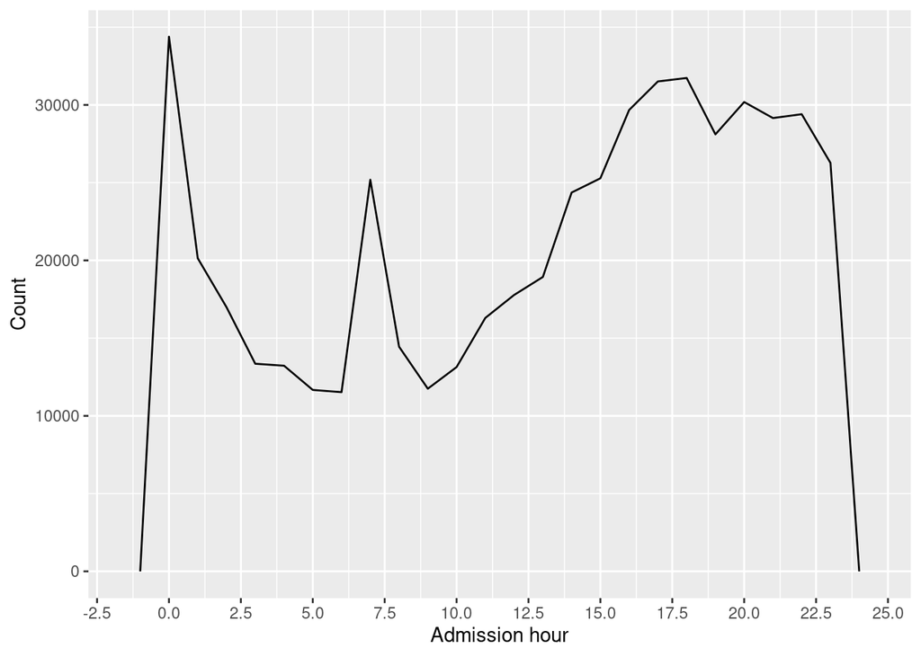

[figure not shown]

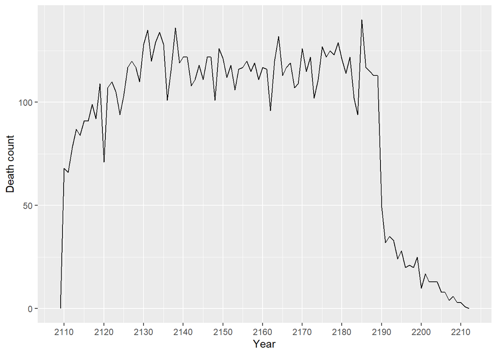

```r
#number of deaths by year
ggplot(yearlydeaths) +
  geom_freqpoly(mapping = aes(x = year),
                binwidth = 1,
                color = "black") +
  scale_x_continuous(n.breaks = 10) +
  xlab("Year") +
  ylab("Death count")
```

A frequency is given for deaths by year, where the value for `hospital_expire_flag` was checked.

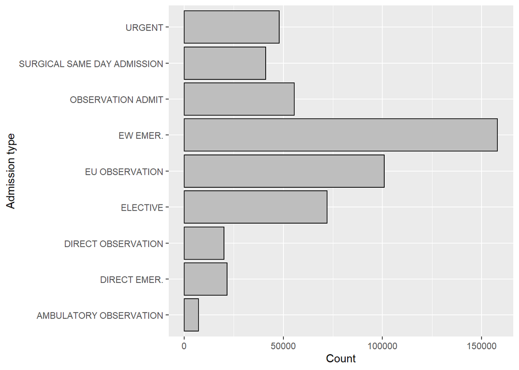

```r
#admission type plot
ggplot(adm) +
  geom_bar(mapping = aes(y = admission_type),
           fill = "grey",
           color = "black") +
  ylab("Admission type") +
  xlab("Count")
```

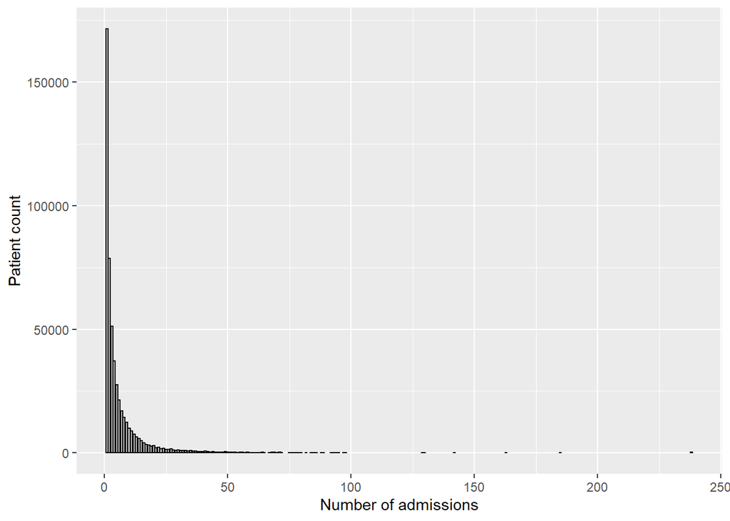

```r
#admission count by patient
ggplot(adm) +
  geom_bar(mapping = aes(x = admitcount),
           fill = "grey",
           color = "black") +
  xlab("Number of admissions") +
  ylab("Patient count")
```

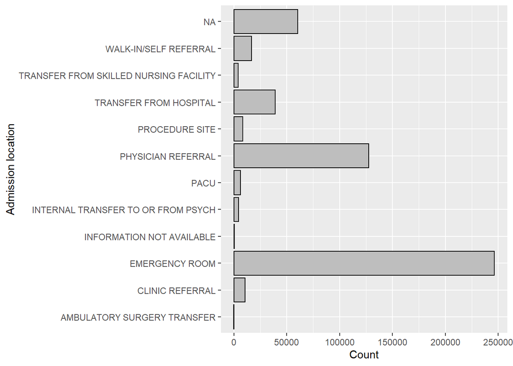

```r
#admission location
ggplot(adm) +
  geom_bar(mapping = aes(y = admission_location),
           fill = "grey",
           color = "black") +
  xlab("Count") +
  ylab("Admission location")
```

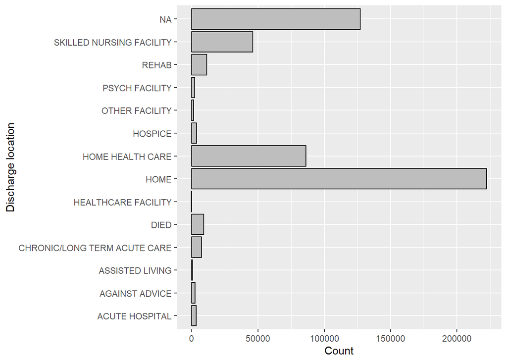

```r
#discharge location
ggplot(adm) +
  geom_bar(mapping = aes(y = discharge_location),
           fill = "grey",
           color = "black") +
  xlab("Count") +
  ylab("Discharge location")
```

Histograms are displayed indicating counts for varying admission types, number of patients with admission counts, patient location prior to hospital arrival, and discharge locations. Number of patients per admission count was chosen because it is a better representation of the distribution of admission number, which is more valuable than information on each individual patient. Clearly, most patients required very few visits, with some requiring multiple visits (up to nearly 250).

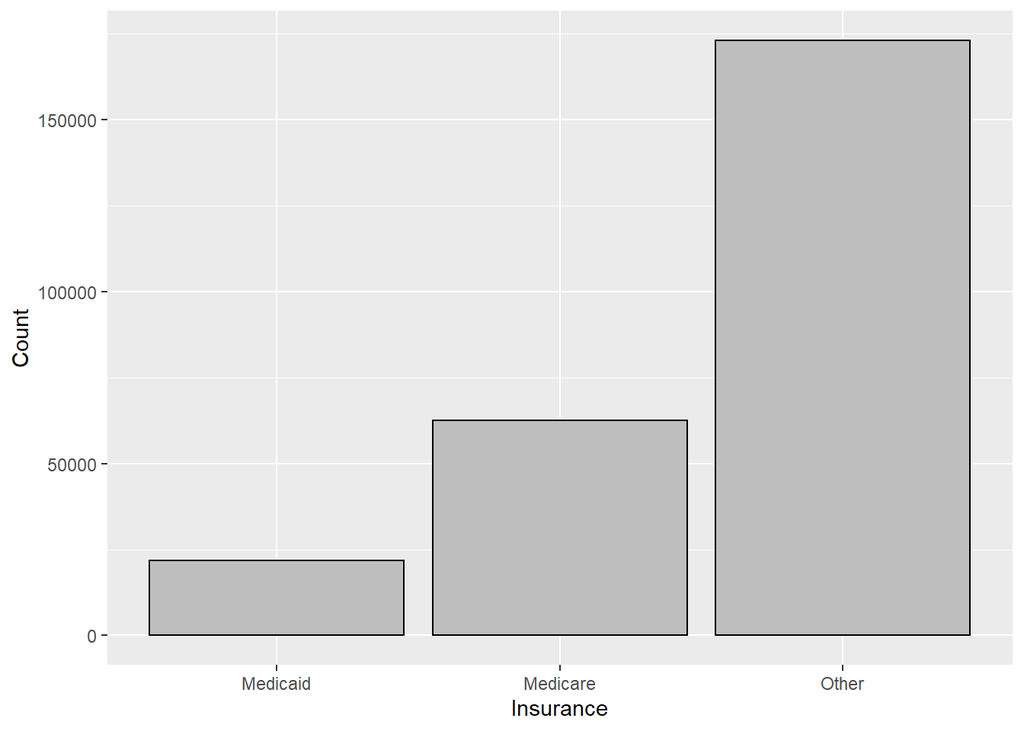

```r
#insurance
ggplot(adm1) +
  geom_bar(mapping = aes(x = insurance),
           fill = "grey",
           color = "black") +
  xlab("Insurance") +
  ylab("Count")
```

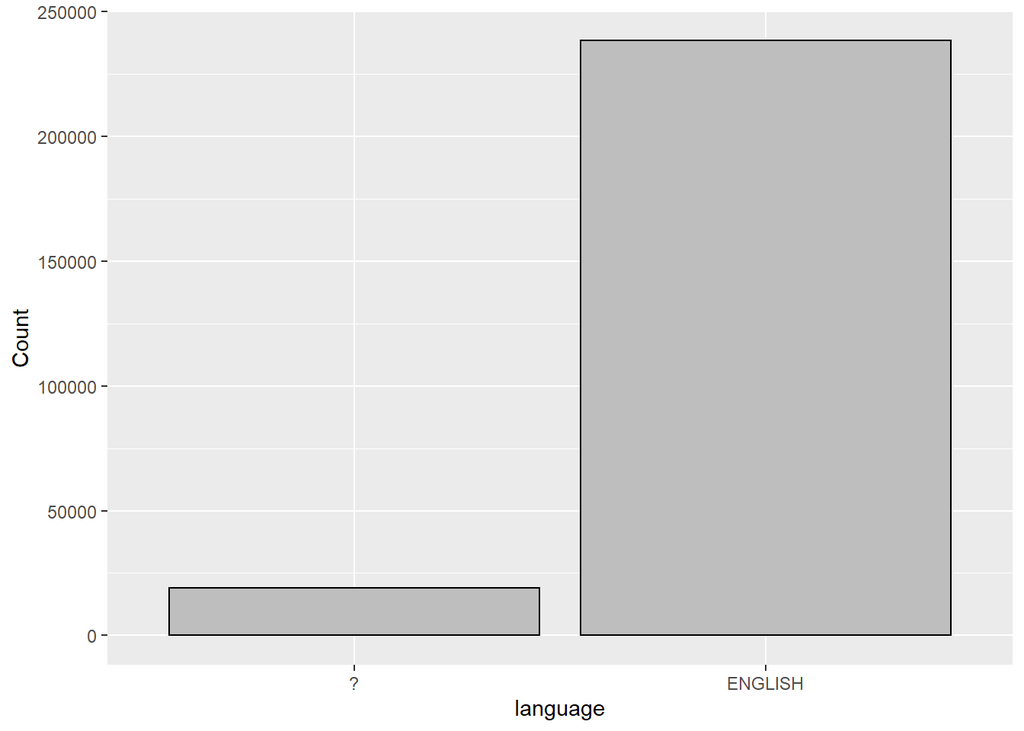

```r
#language
ggplot(adm1) +
  geom_bar(mapping = aes(x = language),
           fill = "grey",
           color = "black") +
  xlab("language") +
  ylab("Count")
```

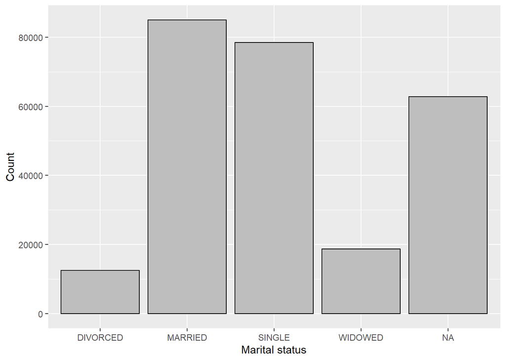

```r
#marital status
ggplot(adm1) +
  geom_bar(mapping = aes(x = marital_status),
           fill = "grey",
           color = "black") +
  xlab("Marital status") +
  ylab("Count")
```

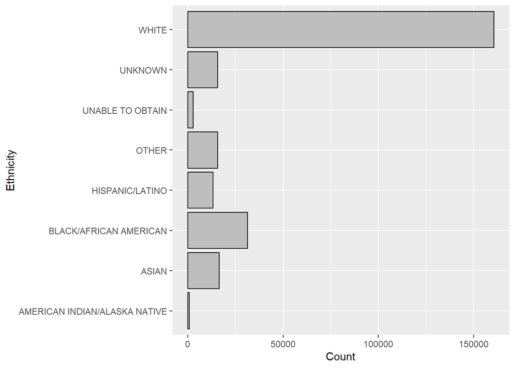

```r
#ethnicity
ggplot(adm1) +
  geom_bar(mapping = aes(y = ethnicity),
           fill = "grey",
           color = "black") +
  ylab("Ethnicity") +
  xlab("Count")
```

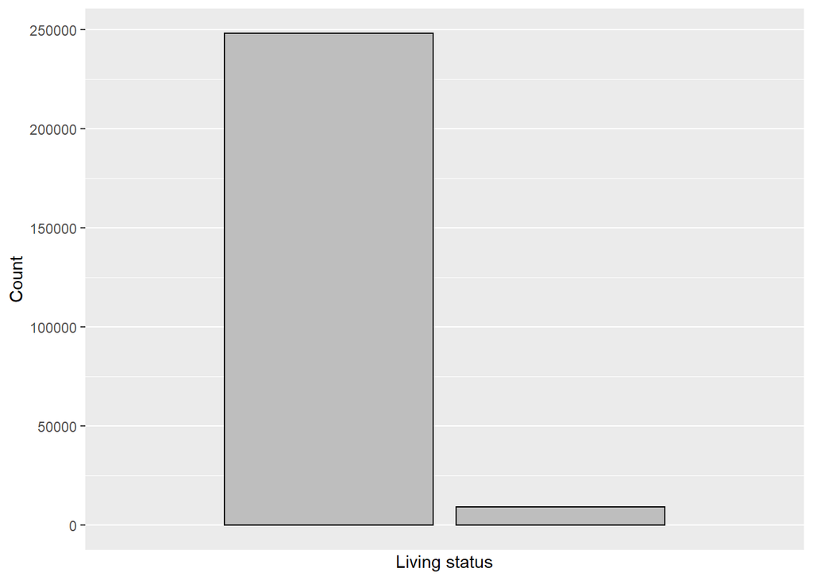

```r
#death
ggplot(adm1) +
  geom_bar(mapping = aes(x = hospital_expire_flag),
           fill = "grey",
           color = "black") +
  scale_x_discrete(labels = c("alive", "deceased")) +
  xlab("Living status") +
  ylab("Count")
```

Histograms are displayed for categorical variables for individual patients (insurance, language, marital status, ethnicity, and living status), from the data-set that only takes patient data from their last admission to the hospital. Last admission was chosen for up-to-date information on patients, most particularly for patient death within the given hospitalization.

## Q5. `patient` data

Explore `patients.csv.gz` (https://mimic-iv.mit.edu/docs/datasets/core/patients/) and summarize following variables using appropriate numerics and graphs:

- `gender`
- `anchor_age` (explain pattern you see)

```r
patients <- read_csv("/usr/203b-data/mimic-iv/core/patients.csv.gz")
```

[output not shown]

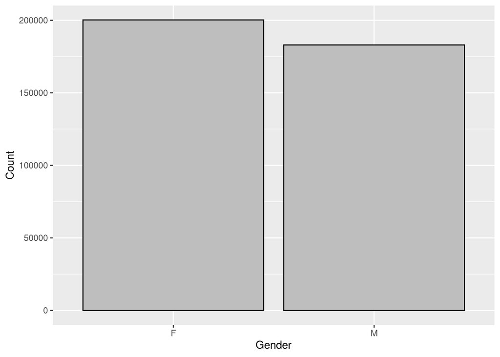

[figure not shown]

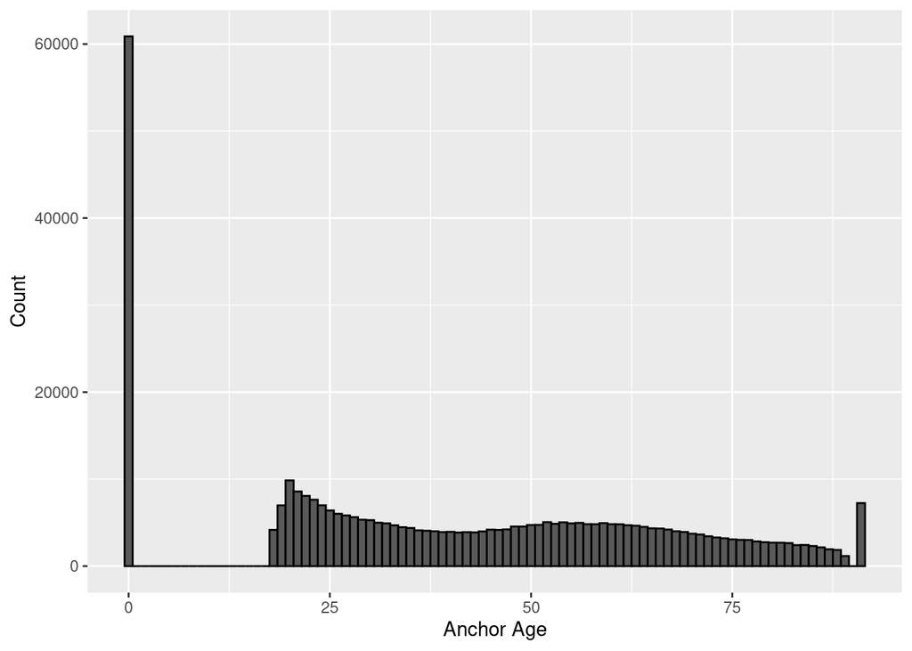

[figure not shown]